# Visualization using a wine data set

Kevin Greenberg

### Introduction

We have a dataset of nearly 130,000 different wines with their ratings, price, tasters, country of origin, variety and much more. That is a lot of wine to look at so we are going to narrow it down to wines from one of my favorite places “Portugal.”

```
## [1] 5691   14
```

Using `dim(df)` we can see that there are 5691 different wines, and 92 varieties. If we put all 92 into a bar graph it’s a little messy, so we are going to ignore the varieties that have a less than 20 wines in them. Now let’s take a look at the different varieties of wine Portugal has to offer.

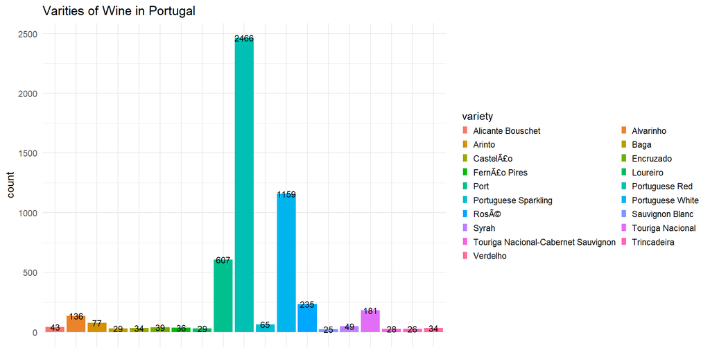

There’s a lot of wines there. I could just show you a table if I used `kable(WP)`, but what’s the fun in that, and it’d be a lot of scrolling. With `DT::datable(WP)` you can search anything in the table.

If you search ‘Port’ you will see there are 607 varieties of Port made in Portugal. We are going to focus on this specific variety of wine.

|  | Variety of wine | Count of Wineries that produce the variety | Average Price (US $) | Average Points |
| --- | --- | --- | --- | --- |
| 1 | Alfrocheiro | 16 | 26.5625 | 88.6875 |
| 2 | Alicante Bouschet | 43 |  | 89.6511627906977 |
| 3 | Alvarelhão | 1 | 24 | 88 |
| 4 | Alvarinho | 136 |  | 88.7941176470588 |
| 5 | Alvarinho-Chardonnay | 5 |  | 87 |
| 6 | Antão Vaz | 17 | 19.7647058823529 | 87.7058823529412 |
| 7 | Aragonês | 10 |  | 88.6 |
| 8 | Aragonez | 10 |  | 87.7 |
| 9 | Arinto | 77 |  | 87.1168831168831 |
| 10 | Avesso | 6 | 16.3333333333333 | 88 |

[output cut: 82 more lines]

### Port Wine

|  | Description | Type | Points | Price (US $) | Winery |
| --- | --- | --- | --- | --- | --- |
| 1 | This is a sweet, rich Port. Its aromas are of soft berry jelly, with a ripe herbal character. To taste, it is concentrated, but the sweetness of the fruit masks its density. Berry and dried fruits mak… | Late Bottled Vintage | 88 |  | Quinta de la Rosa |
| 2 | Ripe and fruity, this is already delicious, but that doesn't detract from the firm tannins and density of a wine that will age well. It has all the elements, with the fruit, solid tannins and a juicy … | Quinta do Seixo Vintage | 94 | 50 | Sandeman |
| 3 | Full of ripe fruit, this wine is rich while also having a delicately perfumed character. With its spice, generous fruits and sense of poise, it will age well. Drink from 2027. | Vintage | 94 | 78 | Quinta do Vesuvio |
| 4 | Ripe, fruity and balanced, this has the potential to be a delicious, not-too-concentrated wine. Acidity and some dry tannins give the wine a firm character that is balanced by the fragrant berry fruit… | Quinta da Gricha Vintage | 94 | 60 | Churchill's |
| 5 | This LBV from the Bulas family vineyards, downriver from Pinhão is all ready to drink. It is fruity with just the right amount of structure. Fresh berry fruits are lifted by fine acidity and well int… | Late Bottled Vintage | 88 | 21 | Bulas |
| 6 | The balance between wood aging and fruit is at its best in this wine. It shows plenty of red fruits filled out with raisins and nutmeg. As a contrast the wood aging has brought out a spicy, almond cha… | 10 Anos Old Tawny | 88 | 30 | Quinta dos Murças |
| 7 | This wine is light in body but heavily perfumed. Clean fruit shows on the palate, with an addition of geranium aromas. | Vintage | 87 | 80 | Quinta do Vale Meão |
| 8 | The pink hue is a little flat. That also applies to the palate, with the fruit showing some maturity and hinting at wood aging. It's a rounded style, full in the mouth, with ripe caramel flavors at th… | Poças Pink | 86 | 15 | Poças |
| 9 | This LBV Port is powered by jammy damson and plum fruits along with dried figs and a juicy aftertaste. The palate is dry, with tannins just in evidence, although the balance is just right. Drink now. | Late Bottled Vintage | 89 | 20 | Delaforce |
| 10 | Kopke has an impressive quantity of old tawnies, some of which will have ended up in this wine. It certainly seems older than its 20 years with strong wood flavors, smoky toast and beautiful mature ac… | 20-Years-Old Tawny | 91 | 56 | Kopke |

[output cut: 597 more lines]

### Price of Port by points

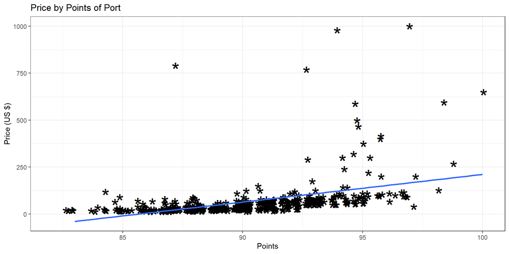

### Count of wineries making Port in Portugal

If we look at the Port by the winery we can tell there are 97 different wineries, by using `wine <- filter(wine, variety == 'Port') %>% group_by(winery) %>% summarise(count = n())`

Now it be great to be able to taste wines from all these different places, but let’s narrow the Ports down to a few you can commonly purchase in the United States.

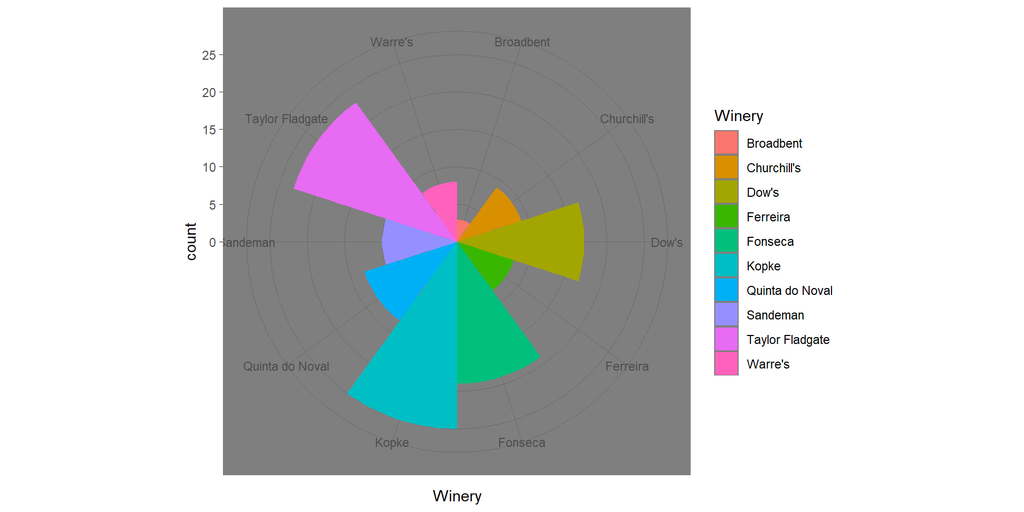

As you can see Taylor Flagate and Kopke have the most Ports in this dataset. Now Lets move away from the data and go look where these Ports come from.

### Location of a a few wineries in Portgual

[interactive chart not shown]

Jump to the Top